# Análisis No Paramétrico: Kruskal-Wallis y Friedman

Ricardo Macías Bohórquez

21 de October de 2024

# Análisis No Paramétrico: Kruskal-Wallis y Friedman

En este documento, aprenderemos a realizar análisis no paramétricos que son equivalentes al ANOVA cuando no se cumplen los supuestos de normalidad. Abordaremos: - **Prueba de Kruskal-Wallis**: Alternativa no paramétrica al ANOVA de una vía para más de dos grupos independientes. - **Prueba de Friedman**: Alternativa no paramétrica al ANOVA de medidas repetidas para comparar varias mediciones en los mismos individuos.

## 1. Conceptos Fundamentales

### 1.1 ¿Por qué usar pruebas no paramétricas?

Las pruebas no paramétricas no requieren que los datos sigan una distribución normal ni suponen homogeneidad de varianzas. Se utilizan para comparar medianas en lugar de medias y son apropiadas cuando los datos son ordinales o cuando hay valores atípicos que distorsionan los resultados de una prueba paramétrica.

### 1.2 Hipótesis en Pruebas No Paramétricas

- **Hipótesis nula (H0)**: No existen diferencias significativas entre los grupos o mediciones.
- **Hipótesis alternativa (H1)**: Existen diferencias significativas entre los grupos o mediciones.

## 2. Prueba de Kruskal-Wallis para Grupos Independientes

### 2.1 Explicación

La prueba de **Kruskal-Wallis** es la alternativa no paramétrica al ANOVA de una vía. Se utiliza para comparar más de dos grupos independientes y evalúa si las distribuciones de los grupos son diferentes.

#### **Hipótesis**:

- **H0**: Las distribuciones de los grupos son iguales.
- **H1**: Al menos un grupo tiene una distribución diferente.

### 2.2 Ejemplo: Comparar `mpg` (Millas por Galón) entre autos con diferente número de cilindros (`cyl`) en `mtcars`

#### 1. Cargar los datos

```r
# Cargar la base de datos mtcars
data(mtcars)

# Convertir la variable cyl a factor
mtcars$cyl <- factor(mtcars$cyl)

# Comparar las medianas de mpg entre los grupos
tapply(mtcars$mpg, mtcars$cyl, median)
```

```
##    4    6    8
## 26.0 19.7 15.2
```

#### 2. Realizar la prueba de Kruskal-Wallis

```r
# Realizar la prueba de Kruskal-Wallis
kruskal_test <- kruskal.test(mpg ~ cyl, data = mtcars)

# Mostrar resultados
print(kruskal_test)
```

```
##
##  Kruskal-Wallis rank sum test
##
## data:  mpg by cyl
## Kruskal-Wallis chi-squared = 25.746, df = 2, p-value = 2.566e-06
```

### 2.3 Interpretación del p-value:

- **Si p < 0.05**, rechazamos la hipótesis nula y concluimos que hay diferencias significativas entre los grupos.
- **Si p ≥ 0.05**, no rechazamos la hipótesis nula y concluimos que no hay suficiente evidencia para afirmar que las distribuciones son diferentes.

## 3. Prueba de Friedman para Mediciones Repetidas

### 3.1 Explicación

La prueba de **Friedman** es la alternativa no paramétrica al ANOVA de medidas repetidas. Se utiliza cuando se toman varias mediciones sobre los mismos sujetos o unidades experimentales y no se cumplen los supuestos de normalidad.

#### **Hipótesis**:

- **H0**: No hay diferencias significativas entre las mediciones.
- **H1**: Hay diferencias significativas entre las mediciones.

### 3.2 Ejemplo: Simulación de un experimento con mediciones repetidas

#### 1. Simular un conjunto de datos de medidas repetidas

```r
# Simular datos de tres mediciones en 10 sujetos
set.seed(123)
sujetos <- factor(rep(1:10, each = 3))
medicion <- factor(rep(c("Tiempo1", "Tiempo2", "Tiempo3"), times = 10))
valor <- rnorm(30, mean = rep(c(80, 85, 88), each = 10), sd = 5)

# Crear un data.frame
df_repetidas <- data.frame(sujetos, medicion, valor)

# Visualizar las primeras filas
head(df_repetidas)
```

```
##   sujetos medicion    valor
## 1       1  Tiempo1 77.19762
## 2       1  Tiempo2 78.84911
## 3       1  Tiempo3 87.79354
## 4       2  Tiempo1 80.35254
## 5       2  Tiempo2 80.64644
## 6       2  Tiempo3 88.57532
```

#### 2. Realizar la prueba de Friedman

```r
# Realizar la prueba de Friedman
friedman_test <- friedman.test(valor ~ medicion | sujetos, data = df_repetidas)

# Mostrar los resultados
print(friedman_test)
```

```
##
##  Friedman rank sum test
##
## data:  valor and medicion and sujetos
## Friedman chi-squared = 2.4, df = 2, p-value = 0.3012
```

### 3.3 Interpretación del p-value:

- **Si p < 0.05**, rechazamos la hipótesis nula y concluimos que hay diferencias significativas entre las mediciones.
- **Si p ≥ 0.05**, no rechazamos la hipótesis nula y concluimos que no hay suficiente evidencia para afirmar que las mediciones son diferentes.

#### 3. Gráfico de las medianas en las diferentes mediciones

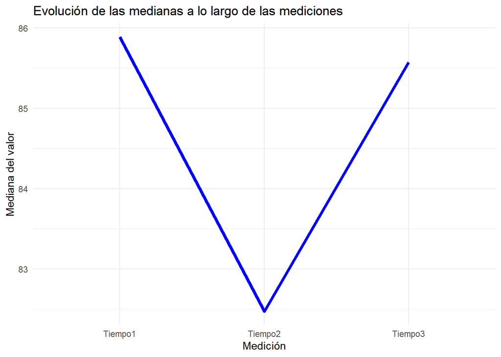

```r
library(ggplot2)

# Gráfico de las medianas por medición
ggplot(df_repetidas, aes(x = medicion, y = valor, group = 4)) +
  stat_summary(fun = median, geom = "line", color = "blue", size = 1.5) +
  labs(title = "Evolución de las medianas a lo largo de las mediciones", x = "Medición", y = "Mediana del valor") +
  theme_minimal()
```

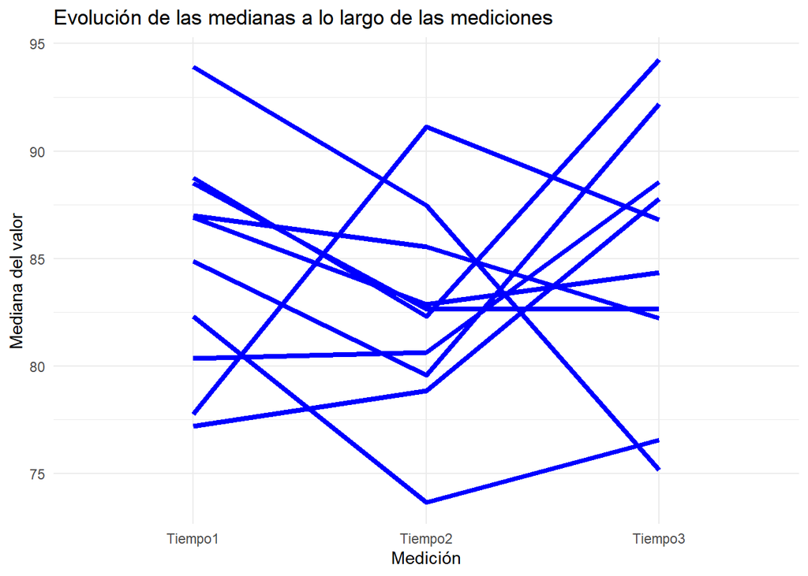

```r
ggplot(df_repetidas, aes(x = medicion, y = valor, group = sujetos)) +
  stat_summary(fun = median, geom = "line", color = "blue", size = 1.5) +
  labs(title = "Evolución de las medianas a lo largo de las mediciones", x = "Medición", y = "Mediana del valor") +
  theme_minimal()
```

## 4. Ejercicios Prácticos

### **Ejercicio 1**: Prueba de Kruskal-Wallis

Usa la base de datos `iris` para comparar la longitud del sépalo (`Sepal.Length`) entre las tres especies de flores. Realiza la prueba de Kruskal-Wallis y discute los resultados.

```r
# Realizar la prueba de Kruskal-Wallis con iris
kruskal_test_iris <- kruskal.test(Sepal.Length ~ Species, data = iris)

# Mostrar resultados
print(kruskal_test_iris)
```

```
##
##  Kruskal-Wallis rank sum test
##
## data:  Sepal.Length by Species
## Kruskal-Wallis chi-squared = 96.937, df = 2, p-value < 2.2e-16
```

### **Ejercicio 2**: Prueba de Friedman

Simula datos de 5 sujetos con 4 mediciones y realiza una prueba de Friedman para comprobar si hay diferencias significativas entre las mediciones.

```r
# Simular datos
set.seed(123)
sujetos <- factor(rep(1:5, each = 4))
medicion <- factor(rep(c("Pre", "Post1", "Post2", "Post3"), times = 5))
valor <- rnorm(20, mean = rep(c(80, 85, 88, 90), each = 5), sd = 3)

# Crear el data.frame
df_pareadas <- data.frame(sujetos, medicion, valor)

# Realizar la prueba de Friedman
friedman_test_pareadas <- friedman.test(valor ~ medicion | sujetos, data = df_pareadas)

# Mostrar los resultados
print(friedman_test_pareadas)
```

```
##
##  Friedman rank sum test
##
## data:  valor and medicion and sujetos
## Friedman chi-squared = 3.48, df = 3, p-value = 0.3234
```